# Ideas that Created the Future_Classic Papers of Computer Science.Lewis2021 — 中英对照

## **13.2 单一错误检测码****13.2 Single Error Detecting Codes**

我们可以用以下方式构造一个具有 *n* 个二进制数字的单错检测码：在前 *n* − 1 个位置放入 *n* − 1 个信息数字。在第 *n* 个位置放入 0 或 1，使全部 *n* 个位置中有偶数个 1。这显然是一个单错检测码，因为传输中的任何单个错误，都会使一个码符号中留下奇数个 1。We may construct a single error detecting code having *n* binary digits in the following manner: In the first *n* − 1 positions we put *n* − 1 digits of information. In the *n*th position we place either 0 or 1, so that the entire *n* positions have an even number of 1s. This is clearly a single error detecting code since any single error in transmission would leave an odd number of 1s in a code symbol.

这些代码的冗余是，因为*m* = *n* − 1，The redundancy of these codes is, since *m* = *n* − 1,

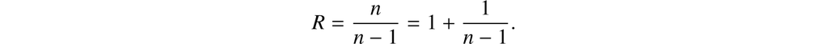

看起来，为了获得低冗余，我们应该让*n*变得非常大。然而，通过增加*n*，符号中至少出现一个错误的概率会增加；而且，出现未被发现的双重错误的风险也会增加。例如，如果*p* ≪ 1 是任何错误的概率，那么对于*n*如此大的 1 */p*，正确符号的概率约为 1 */e* = 0.3679 …，而双重错误的概率为 1/2 *e* = 0.1839 …… _It might appear that to gain a low redundancy we should let *n* become very large. However, by increasing *n*, the probability of at least one error in a symbol increases; and the risk of a double error, which would pass undetected, also increases. For example, if *p* ≪ 1 is the probability of any error, then for *n* so large as 1*/p*, the probability of a correct symbol is approximately 1*/e* = 0.3679…, while a double error has probability 1/2*e* = 0.1839….

上面用于确定符号是否有任何单一错误的检查类型将在整篇论文中使用，称为*奇偶校验*。以上是*偶*校验；如果我们使用奇数个 1 来确定检查位置的设置这将是一个奇怪的奇偶校验。此外，奇偶校验不需要总是涉及符号的所有位置，而是可以仅对选定位置进行检查。The type of check used above to determine whether or not the symbol has any single error will be used throughout the paper and will be called a *parity check*. The above was an *even* parity check; had we used an odd number of 1s to determine the setting of the check position it would have been an odd parity check. Furthermore, a parity check need not always involve all the positions of the symbol but may be a check over selected positions only.

## **13.3 单纠错码****13.3 Single Error Correcting Codes**

为了构造单错纠正码，我们首先从 *n* 个可用位置中指定 *m* 个作为信息位。我们把 *m* 看作固定的，但具体位置留待以后确定。然后把其余 *k* 个位置指定为校验位。这 *k* 个位置上的值，将在编码过程中通过对所选信息位进行偶校验来确定。To construct a single error correcting code we first assign *m* of the *n* available positions as information positions. We shall regard the *m* as fixed, but the specific positions are left to a later determination. We next assign the *k* remaining positions as check positions. The values in these *k* positions are to be determined in the encoding process by even parity checks over selected information positions.

暂且设想我们已经收到一个码符号，它可能有错，也可能无错。依次进行 *k* 次奇偶校验；每当奇偶校验给出的值与其校验位置上观察到的值一致，就写下 0，不一致则写下 1。把这 *k* 个 0 和 1（应与各奇偶校验给出的值区分开）从右向左写成一行，就可以把这一序列看作一个二进制数，称为校验数。我们要求这个校验数给出任何单个错误的位置，并以零值表示该符号中没有错误。因此，校验数必须描述 *m* + *k* + 1 种不同情况，所以 *k* 必须满足条件 2<sup>*k*</sup> ≥ *m* + *k* + 1。记 *n* = *m* + *k*，得到Let us imagine for the moment that we have received a code symbol, with or without an error. Let us apply the *k* parity checks in order, and for each time the parity check assigns the value observed in its check position we write a 0, while for each time the assigned and observed values disagree we write a 1. When written from right to left in a line this sequence of *k* 0s and 1s (to be distinguished from the values assigned by the parity checks) may be regarded as a binary number and will be called the checking number. We shall require that this checking number give the position of any single error, with the zero value meaning no error in the symbol. Thus the check number must describe *m* + *k* + 1 different things, so that 2<sup>*k*</sup> ≥ *m* + *k* + 1 is a condition on *k*. Writing *n* = *m* + *k* we find

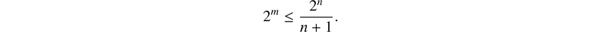

利用这个不等式，可以计算出图 13.1；它给出指定 *n* 时最大的 *m*，或等价地，给出指定 *m* 时最小的 *n*。Using this inequality we may calculate Figure 13.1, which gives the maximum *m* for a given *n*, or, what is the same thing, the minimum *n* for a given *m*.

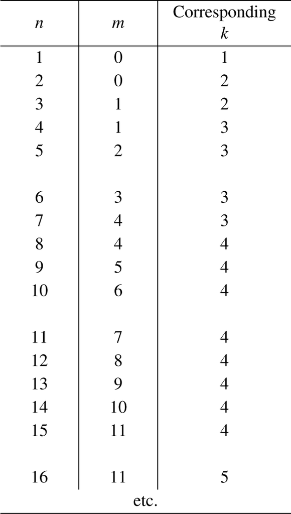

图13.1 Figure 13.1

我们现在确定要应用各种奇偶校验的位置。校验码是从右到左逐位进行奇偶校验，并根据具体情况记下相应的0或1而得到的。由于检查数是给出代码符号中任何错误的位置，因此其二进制表示形式右侧有 1 的任何位置必定会导致第一次检查失败。检查二进制形式我们找到的各种整数We now determine the positions over which each of the various parity checks is to be applied. The checking number is obtained digit by digit, from right to left, by applying the parity checks in order and writing down the corresponding 0 or 1 as the case may be. Since the checking number is to give the position of any error in a code symbol, any position which has a 1 on the right of its binary representation must cause the first check to fail. Examining the binary form of the various integers we find

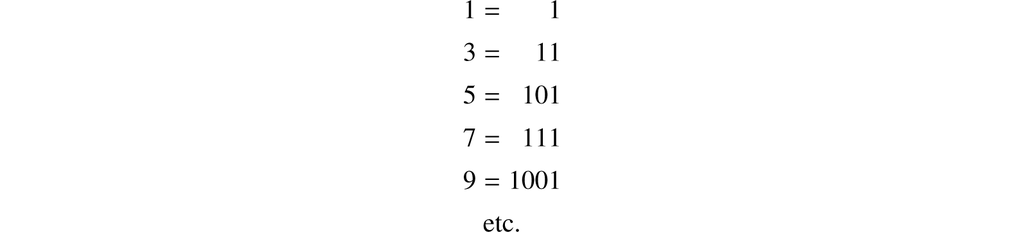

最右边有一个 1。因此，第一个奇偶校验必须使用位置 1, 3, 5, 7, 9 *, ...*。have a 1 on the extreme right. Thus the first parity check must use positions 1, 3, 5, 7, 9*, …*.

以完全相同的方式，我们发现第二个奇偶校验必须使用那些二进制表示右侧第二个数字为 1 的位置，In an exactly similar fashion we find that the second parity check must use those positions which have 1s for the second digit from the right of their binary representation,

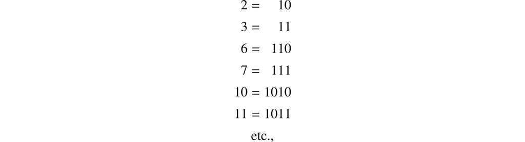

第三次奇偶校验the third parity check

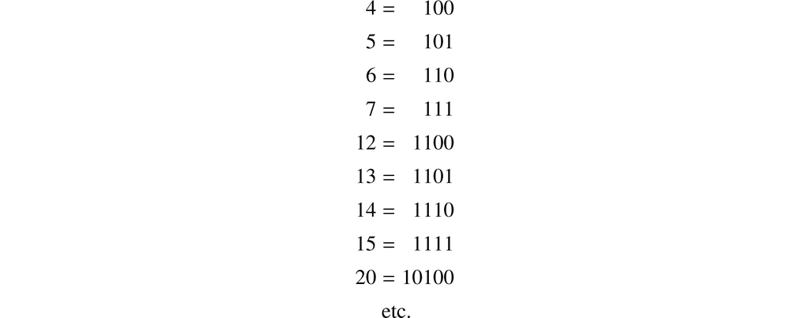

对于每个奇偶校验，仍然需要决定哪些位置包含信息以及哪些位置要进行检查。如下表所示，选择位置 1、2、4、8 ...作为检查位置的优点是使检查位置的设置彼此独立。所有其他位置都是信息位置。由此我们得到图13.2。It remains to decide for each parity check which positions are to contain information and which the check. The choice of the positions 1, 2, 4, 8, … for check positions, as given in the following table, has the advantage of making the setting of the check positions independent of each other. All other positions are information positions. Thus we obtain Figure 13.2.

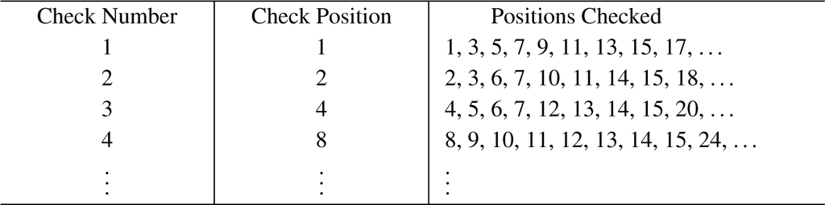

图13.2 Figure 13.2

作为上述理论的说明，我们将其应用于七位代码的情况。从图13.1中我们发现*n* = 7，*m* = 4和*k* = 3。从图13.2中我们发现第一个奇偶校验涉及位置1、3、5、7，用于确定第一个位置的值；第二次奇偶校验，位置2、3、6、7，并确定第二位置的值；和第三次奇偶校验。位置 4、5、6、7，并确定位置 4 的值。这使得位置 3、5、6、7 成为信息位置。使用位置 3、5、6、7 写下所有可能的二进制数，然后计算检查位置 1、2、4 中的值，结果如图 13.3所示。As an illustration of the above theory we apply it to the case of a seven-position code. From Figure 13.1 we find for *n* = 7, *m* = 4 and *k* = 3. From Figure 13.2 we find that the first parity check involves positions 1, 3, 5, 7 and is used to determine the value in the first position; the second parity check, positions 2, 3, 6, 7, and determines the value in the second position; and the third parity check. positions 4, 5, 6, 7, and determines the value in position four. This leaves positions 3, 5, 6, 7 as information positions. The results of writing down all possible binary numbers using positions 3, 5, 6, 7, and then calculating the values in the check positions 1, 2, 4, are shown in Figure 13.3.

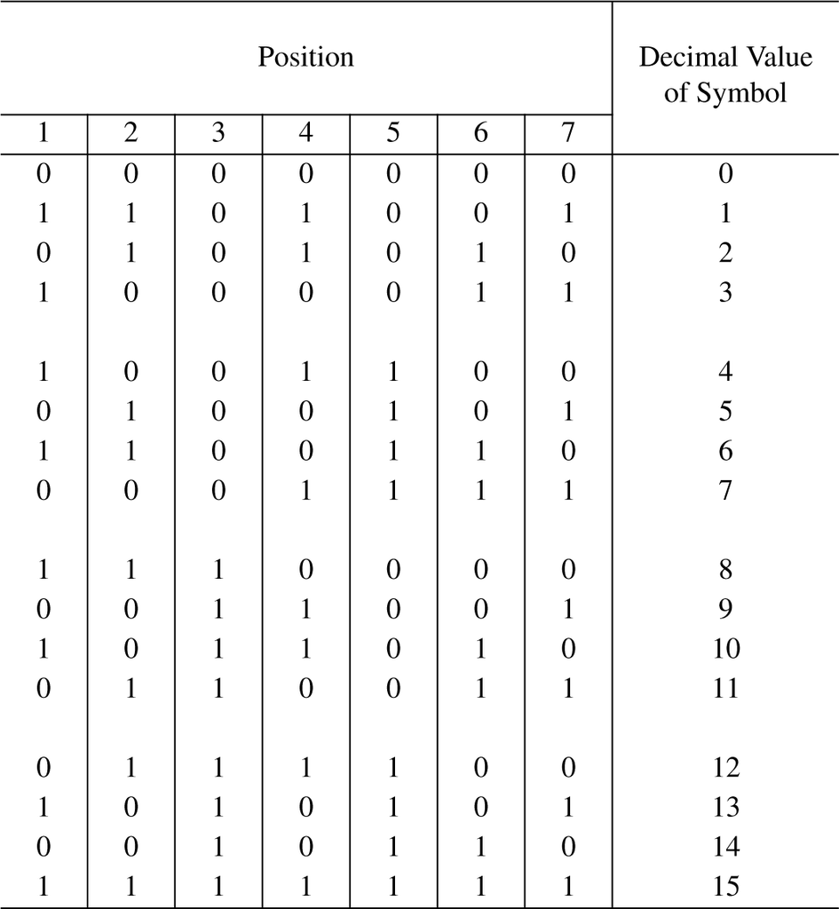

图13.3 Figure 13.3

因此，七位单纠错码允许 16 个代码符号。当然，有 2 <sup>7</sup> − 16 = 112 个无意义的符号。在某些应用中，可能需要从代码中删除第一个符号，以避免全零组合作为代码符号或代码符号加上单个错误，因为这可能会与没有消息相混淆。这仍然会留下 15 个有用的代码符号。Thus a seven-position single error correcting code admits of 16 code symbols. There are, of course, 2<sup>7</sup> − 16 = 112 meaningless symbols. In some applications it may be desirable to drop the first symbol from the code to avoid the all zero combination as either a code symbol or a code symbol plus a single error, since this might be confused with no message. This would still leave 15 useful code symbols.

作为此代码如何“工作”的说明，让我们采用与十进制值 12 相对应的符号 0 1 1 1 1 0 0，并将第五位的 1 更改为 0。现在我们检查新符号 0 1 1 1 0 0 0 通过本节的方法查看错误是如何定位的。从图 13.2中，第一个奇偶校验检查位置 1、3、5、7，并预测第一个位置为 1，而我们在那里找到 0；因此我们写 1。第二个奇偶校验检查位置 2、3、6、7，并正确预测第二个位置：因此我们在 1 的左边写一个 0，得到 0 1。第三个奇偶校验检查位置4、5、6、7，预测错误：所以我们在 0 1 的左边写了一个 1，得到 1 0 1。这个 0 和 1 的序列被视为二进制数，就是数字 5；因此错误位于第五位。因此，将第五位的 0 改为 1 即可获得正确的符号。As an illustration of how this code “works” let us take the symbol 0 1 1 1 1 0 0 corresponding to the decimal value 12 and change the 1 in the fifth position to a 0. We now examine the new symbol 0 1 1 1 0 0 0 by the methods of this section to see how the error is located. From Figure 13.2 the first parity check is over positions 1, 3, 5, 7 and predicts a 1 for the first position while we find a 0 there; hence we write a 1. The second parity check is over positions 2, 3, 6, 7 and predicts the second position correctly: hence we write a 0 to the left of the 1, obtaining 0 1. The third parity check is over positions 4, 5, 6, 7 and predicts wrongly: hence we write a 1 to the left of the 0 1, obtaining 1 0 1. This sequence of 0s and 1s regarded as a binary number is the number 5; hence the error is in the fifth position. The correct symbol is therefore obtained by changing the 0 in the fifth position to a 1.

## **13.4 单纠错加双检错码****13.4 Single Error Correcting Plus Double Error Detecting Codes**

为了构建单纠错加双检错码，我们从单纠错码开始。在此代码中，我们使用偶校验检查添加了一个位置来检查所有先前的位置。要了解此代码的操作，我们必须检查多种情况：To construct a single error correcting plus double error detecting code we begin with a single error correcting code. To this code we add one more position for checking all the previous positions, using an even parity check. To see the operation of this code we have to examine a number of cases:

1. 没有错误。所有奇偶校验（包括最后的奇偶校验）均得到满足。1. No errors. All parity checks, including the last, are satisfied.

2.单一错误。在所有这些情况下，最后的奇偶校验都会失败，无论错误是在信息、原始检查位置还是最后的检查位置。原始检查编号给出了错误的位置，现在零值表示最后的检查位置。2. Single error. The last parity check fails in all such situations whether the error be in the information, the original check positions, or the last check position. The original checking number gives the position of the error, where now the zero value means the last check position.

3.两个错误。在所有这些情况下，最后的奇偶校验都得到满足，并且检查编号指示某种错误。3. Two errors. In all such situations the last parity check is satisfied, and the checking number indicates some kind of error.

第二部分。一般理论PART II. GENERAL THEORY

## **13.5 几何模型****13.5 A Geometric Model**

在考察与检错码和纠错码有关的各种问题时，引入几何模型往往很方便。这里使用的模型，是把构成一个码的各个符号的 0、1 序列，与单位 *n* 维立方体的顶点一一对应。标记为 *x*、*y*、*z*、… 的码点，构成立方体全部顶点集的一个子集。我们在这个由 2<sup>*n*</sup> 个点组成的空间中引入*距离*，或通常所说的*度量* *D*(*x, y*)。这一度量的定义基于如下观察：码点中的一个错误改变一个坐标，两个错误改变两个坐标，而一般地，*d* 个错误造成 *d* 个坐标的差异。因此，我们把两点 *x* 与 *y* 之间的距离 *D*(*x, y*)，定义为 *x* 与 *y* 不相同的坐标的数量。这也就是从 *x* 到 *y* 必须经过的最少边数。这个距离函数满足度量通常应满足的三个条件，即：When examining various problems connected with error detecting and correcting codes it is often convenient to introduce a geometric model. The model used here consists in identifying the various sequences of 0s and 1s which are the symbols of a code with vertices of a unit *n*-dimensional cube. The code points, labelled *x*, *y*, *z*, …, form a subset of the set of all vertices of the cube. Into this space of 2<sup>*n*</sup> points we introduce a *distance*, or, as it is usually called, a *metric*, *D*(*x, y*). The definition of the metric is based on the observation that a single error in a code point changes one coordinate, two errors, two coordinates, and in general *d* errors produce a difference in *d* coordinates. Thus we define the distance *D*(*x, y*) between two points *x* and *y* as the number of coordinates for which *x* and *y* are different. This is the same as the least number of edges which must be traversed in going from *x* to *y*. This distance function satisfies the usual three conditions for a metric, namely,

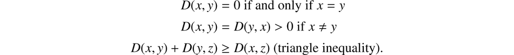

例如，注意到三维立方体中的下列码点彼此相距均为两个单位：0 0 1；0 1 0；1 0 0；1 1 1。继续使用几何语言，我们把以点 *x* 为中心、半径为 *r* 的球定义为距点 *x* 的距离为 *r* 的所有点。因此，在上例中，前三个码点位于以点 (1, 1, 1) 为中心、半径为 2 的球上。事实上，在这个例子中，可以任选一个码点作为球心，其余三个码点都将位于半径为 2 的球面上。As an example we note that each of the following code points in the three-dimensional cube is two units away from the others: 0 0 1; 0 1 0; 1 0 0; 1 1 1. To continue the geometric language, a sphere of radius *r* about a point *x* is defined as all points which are at a distance *r* from the point *x*. Thus, in the above example, the first three code points are on a sphere of radius 2 about the point (1, 1, 1). In fact, in this example any one code point may be chosen as the center and the other three will lie on the surface of a sphere of radius 2.

如果所有代码点彼此之间的距离至少为 2，则任何单个错误都会将代码点转移到不是代码点的点，因此是一个无意义的符号。这又意味着任何单个错误都是可检测到的。如果码点之间的最小距离至少为三个单位，则任何单个错误都会使该点比任何其他码点更接近正确的码点，这意味着任何单个错误都是可纠正的。图 13.5总结了此类信息。If all the code points are at a distance of at least 2 from each other, then it follows that any single error will carry a code point over to a point that is not a code point, and hence is a meaningless symbol. This in turn means that any single error is detectable. If the minimum distance between code points is at least three units then any single error will leave the point nearer to the correct code point than to any other code point, and this means that any single error will be correctable. This type of information is summarized in Figure 13.5.

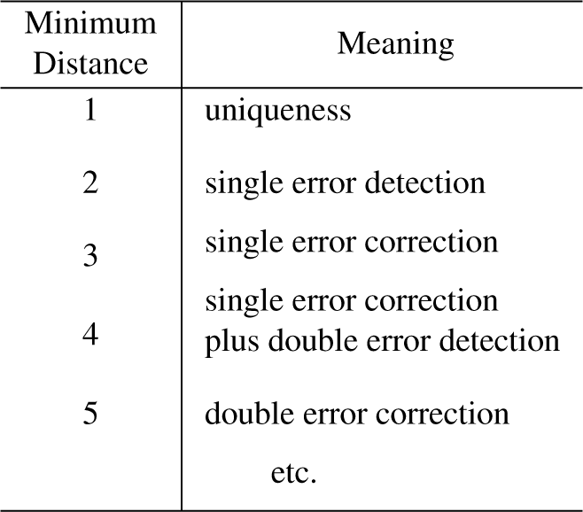

图13.5 Figure 13.5

或许应该指出的是，在给定的最小距离处，一些可校正性可以被交换为更多的可检测性。例如，最小距离为 5 的子集可用于：It should perhaps be noted that, at a given minimum distance, some of the correctability may be exchanged for more detectability. For example, a subset with minimum distance 5 may be used for:

A。双错误校正（当然，还有双错误检测）a. double error correction (with, of course, double error detection)

b. 单错误纠正加三错误检测b. single error correction plus triple error detection

C。四重错误检测。c. quadruple error detection.

现在回到第一部分中构建的特定代码，我们注意到代码中位置的任何交换都不会以任何本质的方式改变代码。交换任意位置的 0 和 1 也不行，这一过程通常称为补码。这个想法在以下定义中更加精确：Returning for the moment to the particular codes constructed in Part I we note that any interchanges of positions in a code do not change the code in any essential way. Neither does interchanging the 0s and 1s in any position, a process usually called complementing. This idea is made more precise in the following definition:

*定义。*如果通过以下有限数量的操作，可以将一个代码转换为另一个代码，则称两个代码彼此*等效：**Definition.* Two codes are said to be *equivalent* to each other if, by a finite number of the following operations, one can be transformed into the other:

1、代码符号中任意两个位置的互换。1. The interchange of any two positions in the code symbols.

2、代码符号中任意位置数值的补码。2. The complementing of the values in any position in the code symbols.

这是一个正式的等价关系 ( *∼* )，因为*A ∼ A*；*A ∼ B*意味着*B ∼ A*；并且*A ∼ B* , *B ∼ C*意味着*A ∼ C*。因此，我们可以将对一类代码的研究简化为对每个等价类的典型成员的研究。就几何模型而言，等价变换相当于单位立方体的旋转和反射。This is a formal equivalence relation (*∼*) since *A ∼ A*; *A ∼ B* implies *B ∼ A*; and *A ∼ B*, *B ∼ C* implies *A ∼ C*. Thus we can reduce the study of a class of codes to the study of typical members of each equivalence class. In terms of the geometric model, equivalence transformations amount to rotations and reflections of the unit cube.